# My Spotify Project

Author

Zoë Ip

# Billie Eilish

## What about her…?

### Some quick facts

- As of Feb 2025: 108 million monthly listeners on Spotify
- The third artist ever to surpass 100 million monthly listeners
- Spotify’s top fourth artist, but also a climate, political, and feminist activist

### Billie Eilish on Vanity Fair, June 2018

> *I’m trying to show everybody that I’m a girl, and I’m five foot four, and you can do anything you want, no matter your gender. It’s your world, too!*

[figure not shown]

### Her most iconic music video – surpassing 1 billion views

[bad guy (2019, Youtube link)](https://youtu.be/DyDfgMOUjCI?si=uITrJgKVnwhzoiIf)

[video not shown]

## Data analysis

### Data source

My data is from an excel spreadsheet, named “Billie Eilish.csv”, provided by Dr. Joy Lee.

### Import data

```r
# These are packages I need for the analysis
library(ggplot2)
library(dplyr)

# To read my dataset
df <- read.csv("Billie Eilish.csv")
```

### What’s in the data? Let’s take a peek:

```r
# Take 5 random records in the dataframe
df |>
  dplyr::slice_sample(n = 5) |>
  knitr::kable(digits = 2, format = "html", caption = "Some of Billie Eilish's songs") |>
  kableExtra::kable_styling(full_width = FALSE, font_size = 14, bootstrap_options = c("striped", "hover")) |>

# Makes first column bold and green
  kableExtra::row_spec(0, bold = TRUE, background = "grey", color = "white") |>
  kableExtra::column_spec(1, bold = TRUE, color = "green")
```

Some of Billie Eilish's songs

| artist_name | track_name | track_number | album_name | album_release_year | energy | valence | danceability | loudness | speechiness | liveness | tempo | key_mode | duration_ms |
| --- | --- | --- | --- | --- | --- | --- | --- | --- | --- | --- | --- | --- | --- |
| Billie Eilish | Your Power | 12 | Happier Than Ever | 2021 | 0.28 | 0.21 | 0.63 | -14.03 | 0.08 | 0.23 | 129.64 | A minor | 245896 |
| Billie Eilish | ilomilo | 11 | WHEN WE ALL FALL ASLEEP, WHERE DO WE GO? | 2019 | 0.42 | 0.57 | 0.86 | -15.04 | 0.06 | 0.09 | 120.02 | F minor | 156370 |
| Billie Eilish | bury a friend | 10 | WHEN WE ALL FALL ASLEEP, WHERE DO WE GO? | 2019 | 0.39 | 0.20 | 0.90 | -14.51 | 0.33 | 0.11 | 120.05 | G# major | 193143 |
| Billie Eilish | !!!!!!! | 1 | WHEN WE ALL FALL ASLEEP, WHERE DO WE GO? | 2019 | 0.28 | 0.00 | 0.00 | -21.63 | 0.00 | 0.67 | 0.00 | C# major | 13578 |
| Billie Eilish | you should see me in a crown | 4 | WHEN WE ALL FALL ASLEEP, WHERE DO WE GO? | 2019 | 0.53 | 0.32 | 0.68 | -10.48 | 0.19 | 0.14 | 150.46 | E major | 180952 |

## **Album analysis (energy, valence, and speechiness)**

[figure not shown]

*WHEN WE ALL FALL ASLEEP, WHERE DO WE GO?* and *Happier Than Ever*

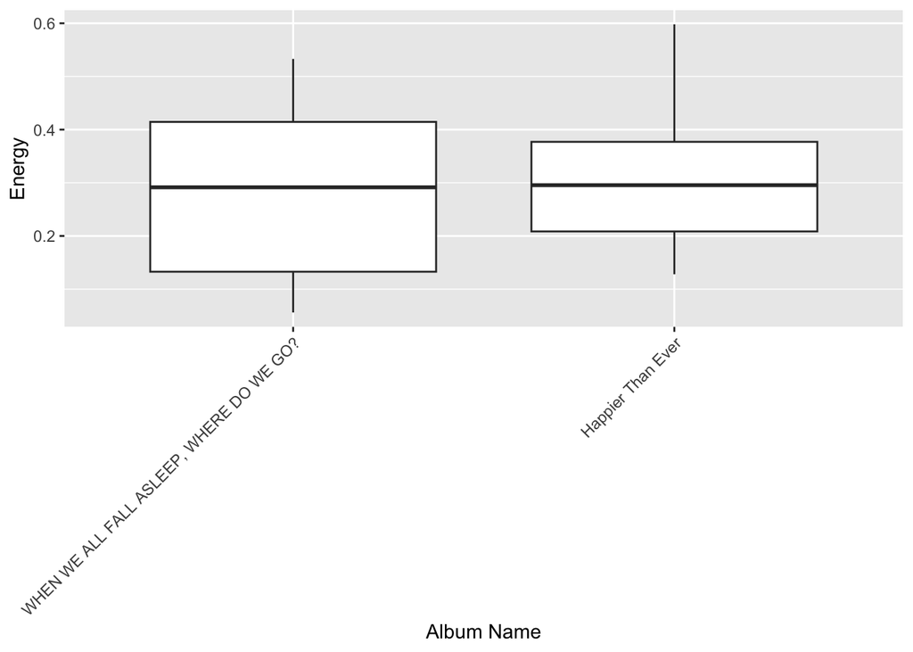

```r
ggplot(df, aes(x=reorder(album_name, energy, median), y=energy)) +
  geom_boxplot() +
  labs(x="Album Name", y="Energy") +
  theme(axis.text.x = element_text(angle=45, hjust=1))
```

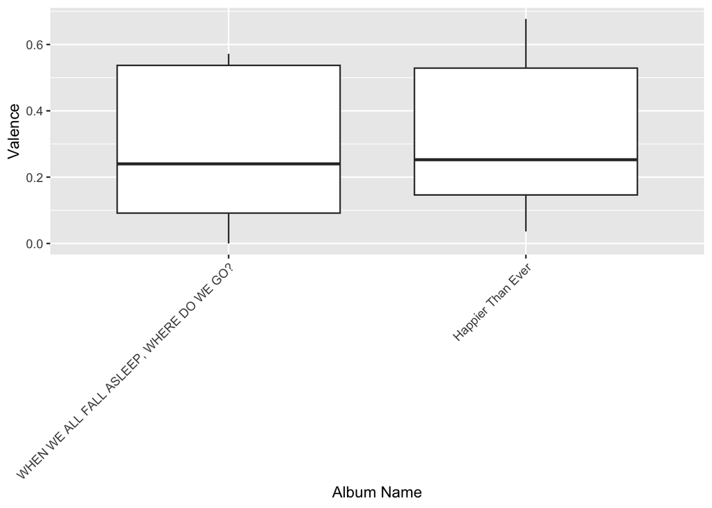

```r
ggplot(df, aes(x=reorder(album_name, valence, median), y=valence)) +
  geom_boxplot() +
  labs(x="Album Name", y="Valence") +
  theme(axis.text.x = element_text(angle=45, hjust=1))
```

Both albums share the same median energy and valence! And similar spreads, only the album *Happier Than Ever* has less variation in both boxplots.

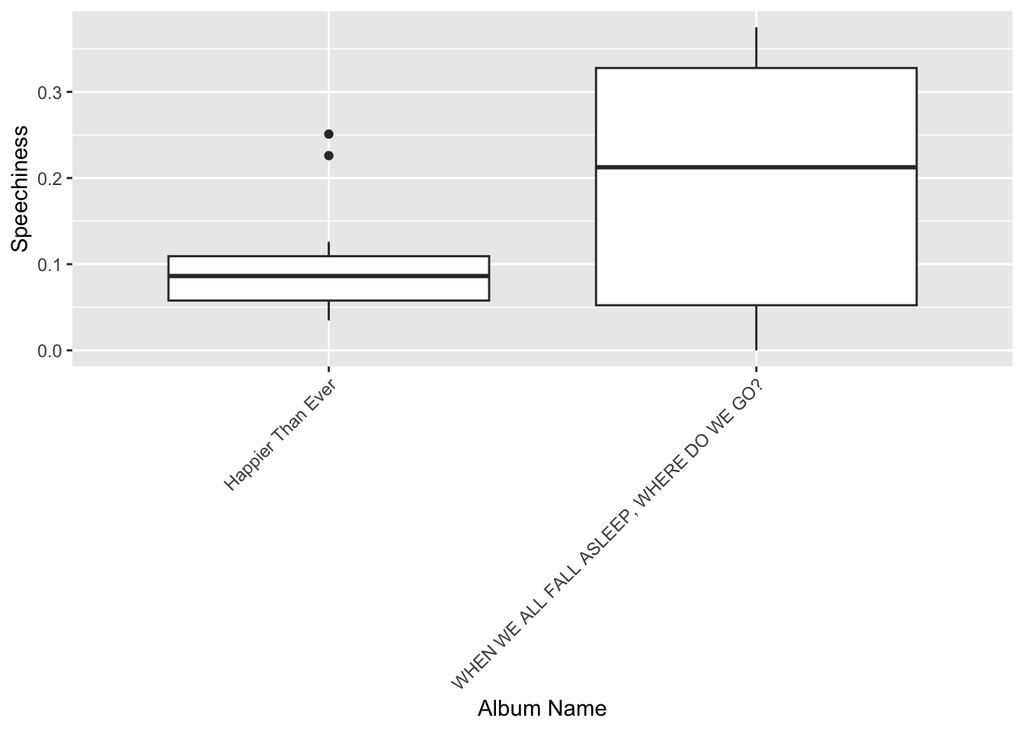

```r
ggplot(df, aes(x=reorder(album_name, speechiness, median), y=speechiness)) +
  geom_boxplot() +
  labs(x="Album Name", y="Speechiness") +
  theme(axis.text.x = element_text(angle=45, hjust=1))
```

However, there are noticeable differences in speechiness!

Let’s listen to an outlier with a high speechiness from *Happier Than Ever*…

[Lost Cause Live (2019, Youtube link)](https://youtu.be/vuhYSH36aSM?si=ze_0eOvAEOwjTm-6)

[video not shown]

Let’s listen to a track with a low speechiness from *Happier Than Ever*…

[Happier Than Ever Live (2022, Youtube link)](https://youtu.be/H_hgw-V-wBI?si=xc5JQLgqVsTAPBlD)

[video not shown]

## Is she really *Happier Than Ever?*

### What is her most happy and uplifting song?

#### Billie Eilish’s top 5 most positive songs!

```r
# Find top 5 songs by valence, style the table
df |>
  slice_max(valence, n = 5) |>
  dplyr::select(track_name, album_name, valence) |>
  knitr::kable(digits = 2, format = "html", caption = "Top 5 Songs by Valence") |>
  kableExtra::kable_styling(
    full_width = FALSE,           # Prevents table from spanning the entire page width
    font_size = 14,               # Sets the font size to 14 for better readability
    bootstrap_options = c("striped", "hover")  # Adds striped rows and hover effect
  ) |>
  kableExtra::row_spec(0, bold = TRUE, background = "grey", color = "white") |>  # Bold header with dark background
  kableExtra::column_spec(1, bold = TRUE, color = "green")  # Makes the first column (track_name) bold and green
```

Top 5 Songs by Valence

| track_name | album_name | valence |
| --- | --- | --- |
| I Didn't Change My Number | Happier Than Ever | 0.68 |
| Therefore I Am | Happier Than Ever | 0.66 |
| ilomilo | WHEN WE ALL FALL ASLEEP, WHERE DO WE GO? | 0.57 |
| all the good girls go to hell | WHEN WE ALL FALL ASLEEP, WHERE DO WE GO? | 0.57 |
| my strange addiction | WHEN WE ALL FALL ASLEEP, WHERE DO WE GO? | 0.56 |

#### Billie Eilish’s top 5 energetic songs:

```r
# Slice top 5 songs by energy and style the table
df |>
  slice_max(energy, n = 5) |>
  dplyr::select(track_name, album_name, energy) |>
  knitr::kable(digits = 2, format = "html", caption = "Top 5 Songs by Energy") |>
  kableExtra::kable_styling(
    full_width = FALSE,           # Prevents table from spanning the entire page width
    font_size = 14,               # Sets the font size to 14 for better readability
    bootstrap_options = c("striped", "hover")  # Adds striped rows and hover effect
  ) |>
  kableExtra::row_spec(0, bold = TRUE, background = "grey", color = "white") |>  # Bold header with dark background
  kableExtra::column_spec(1, bold = TRUE, color = "green")  # Makes the first column (track_name) bold and green
```

Top 5 Songs by Energy

| track_name | album_name | energy |
| --- | --- | --- |
| Oxytocin | Happier Than Ever | 0.60 |
| you should see me in a crown | WHEN WE ALL FALL ASLEEP, WHERE DO WE GO? | 0.53 |
| OverHeated | Happier Than Ever | 0.52 |
| I Didn't Change My Number | Happier Than Ever | 0.48 |
| all the good girls go to hell | WHEN WE ALL FALL ASLEEP, WHERE DO WE GO? | 0.44 |

Billie Eilish’s most happy song is thus *I Didn’t Change My Number*. Although the lyrics do not necessarily reflect positivity:

> Don’t take it out on me  
> I’m out of sympathy for you  
> Maybe you should leave  
> Before I get too mean  
> And take it out on you  
> And your best friend too

While it may not be the most uplifting song, its confident and assertive tone makes it a strong self-empowerment anthem!

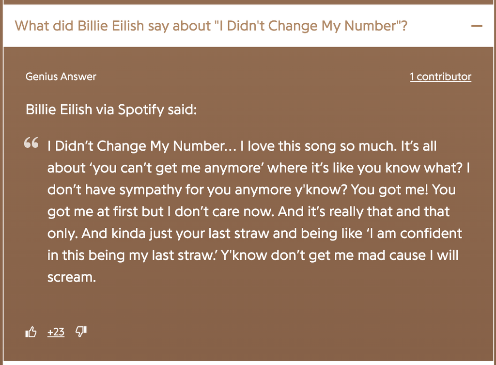

### But… can we dance to Billie Eilish?

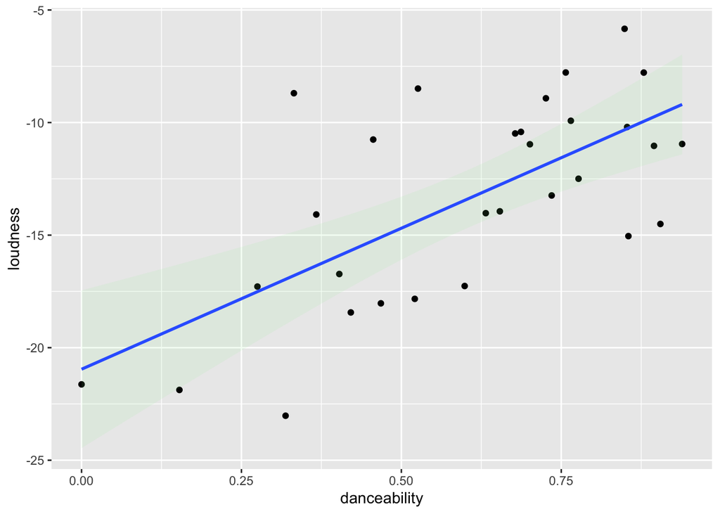

```r
ggplot(df, aes(x = danceability, y = loudness)) +
  geom_point() +
  geom_smooth(method = "lm", alpha = 0.1, fill = "lightgreen")
```

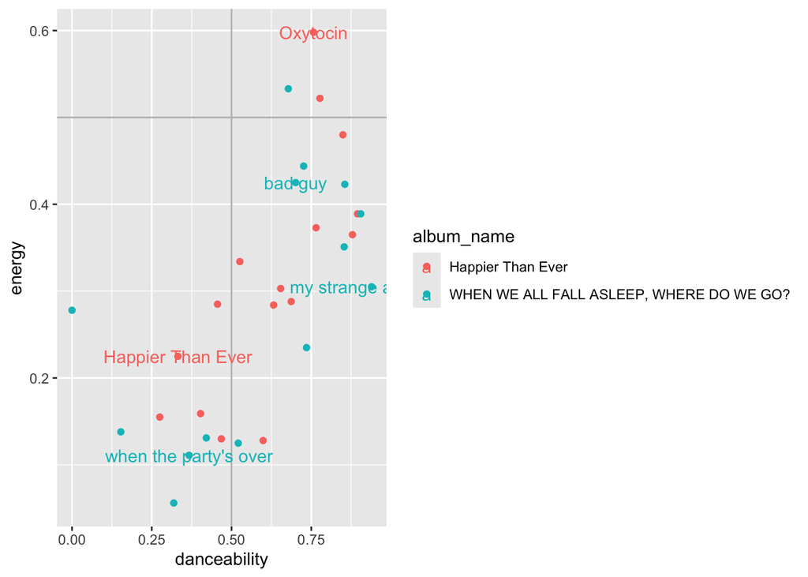

```r
# Filter for specific songs
subgroup <- df |>
  filter(track_name %in% c("bad guy", "Happier Than Ever", "when the party's over", "Oxytocin", "my strange addiction"))

# Create the plot
ggplot(df, aes(x = danceability, y = energy, color = album_name)) +
  geom_point() +
  geom_hline(yintercept = 0.5, color = "grey") +
  geom_vline(xintercept = 0.5, color = "grey") +
  geom_text(data = subgroup, aes(label = track_name), check_overlap = TRUE)
```

Billie Eilish has songs with all levels of danceability! From essentially the lowest to the highest level of danceability!

## 2020 Grammys: Billie Eilish

She won five out of the six awards she was nominated for. *WHEN WE ALL FALL ASLEEP, WHERE DO WE GO?* being “album of the year”, and *bad guy* being “song of the year”.

[figure not shown]

Billie Eilish, source: 2020 Vanity Fair